# Practica Regresion

## David Montero Loaiza

Cargar datos:

```r
# UBICACION DE LOS DATOS
path = "C:/Users/Dave Mont/Desktop/Estadistica/Práctica Regresión lineal y Maxima Verosimilitud-20191120/CdP_practica_estadistica.csv"

# LEER DATOS
df = read.csv(path,header = TRUE)

# FORMATEAR FECHA
df$date = as.Date(df$date,format = "%d/%m/%Y")

# ELIMINAR NAN
df = df[!is.nan(df$AVG.Temp.),]

# SELECCIONAR COLUMNAS NECESARIAS
df = df[,c(1,4,5)]
names(df) = c("Fecha","Conductividad","Salinidad")

# DATOS DEL 2014 Y 2015 POR APARTE
df2014 = df[df$Fecha < as.Date("2015-01-01",format = "%Y-%m-%d"),]
df2015 = df[df$Fecha > as.Date("2014-12-31",format = "%Y-%m-%d"),]
```

Grafica.

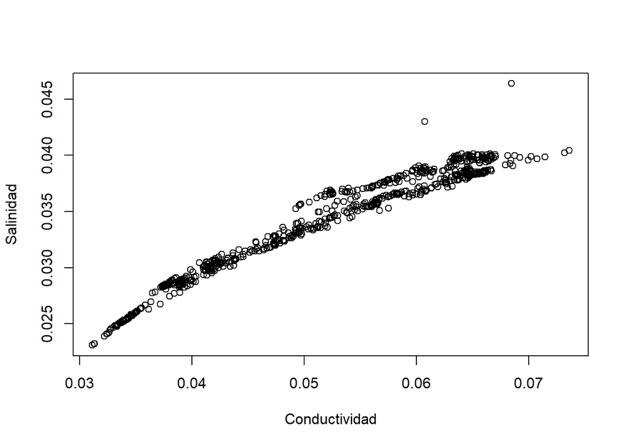

```r
# GRAFICA DE CONDUCTIVIDAD VS SALINIDAD
plot(df$Conductividad,df$Salinidad,xlab = "Conductividad",ylab = "Salinidad")
```

### 1. Modelo de Regresión lineal con un “feature” para los datos Salinidad 2014 vs Conductividad 2014.

```r
# X y Y PARA LOS DATOS DE 2014
x = df2014$Conductividad
y = df2014$Salinidad
```

#### 1.1 - Utilizando como función de coste el cuadrado de la distancia euclídea. Calcular de forma analitica, los coeficientes que minimizan la función de coste.

```r
# VARIABLE PARA GUARDAR COEFICIENTES
alpha_analitica = NULL

# COEFICIENTES CALCULADOS DE MANERA ANALITICA
alpha_analitica[2] = (mean(x*y) - mean(x)*mean(y)) / (mean(x^2) - mean(x)^2)
alpha_analitica[1] = mean(y) - alpha_analitica[2] * mean(x)
```

#### 1.2 Caso general. Para los datos Salinidad 2014 vs Conductividad 2014, calcular los coeficientes usando matrices.

Construye una función que reciba los vectores “x” e “y” y que calcule los valores de los coeficientes que minimizan la función de coste.

```r
# FUNCION PARA GENERAR LA MATRIZ X A PARTIR DEL VECTOR x Y EL GRADO DEL POLINOMIO
generate_X = function(x,gpoly){

  X = rep(1,length(x))

  for(i in 1:gpoly){

    X = cbind(X,x^i)

  }

  return(X)

}

# FUNCION PARA CALCULAR LOS VALORES DE LOS COEFICIENTES QUE MINIMIZAN LA FUNCION DE COSTE
loss_min = function(X,y){

  a = solve(t(X) %*% X) %*% t(X) %*% y
  return(a)

}

# MATRIZ X CON GRADO 1
X = generate_X(x,1)

# COEFICIENTES CALCULADOS DE MANERA MATRICIAL
alpha_matricial = loss_min(X,y)
```

#### 1.3 Compara ambos resultados con el obtenido mediante la función “lm” implementada en R.

```r
# MODELO LM EN R
model = lm(y ~ x)

# COEFICIENTES DEL MODELO
alpha_model = model$coefficients

# COMPARACION DE LOS TRES PARES DE COEFICIENTES OBTENIDOS EN UN DATA FRAME
coef_df = data.frame("Coeficientes_Analiticamente" = alpha_analitica,
                     "Coeficientes_Matricialmente" = alpha_matricial,
                     "Coeficientes_Modelo_R)" = alpha_model)

coef_df
```

|  | Coeficientes_Analiticamente | Coeficientes_Matricialmente | Coeficientes_Modelo_R. |
| --- | --- | --- | --- |
| X | 0.01112899 | 0.01112899 | 0.01112899 |
|  | 0.43701462 | 0.43701462 | 0.43701462 |

### 2. Modelo no lineal para los datos Salinidad 2014 vs Conductividad 2014.

Construye una función que reciba los vectores “x” e “y” y calcule los valores de los coeficientes que minimizan la función de coste.

#### 2.1 Polinomio de grado 2.

```r
# MATRIZ X CON GRADO 2
X_poly2 = generate_X(x,2)

# COEFICIENTES DEL POLINOMIO CON GRADO 2
alpha_poly2_matricial = loss_min(X_poly2,y)
```

#### 2.2 Polinomio de grado 3.

```r
# MATRIZ X CON GRADO 3
X_poly3 = generate_X(x,3)

# COEFICIENTES DEL POLINOMIO CON GRADO 3
alpha_poly3_matricial = loss_min(X_poly3,y)
```

#### 2.3 Compara los coeficientes calculados, con los obtenidos con la función “glm” implementada en R. “glm(y~poly(x,grado del polinomio))”

```r
# MODELO GLM EN R
glm_poly2 = glm(y ~ poly(x,2,raw = TRUE))
glm_poly3 = glm(y ~ poly(x,3,raw = TRUE))

# COEFICIENTES DE LOS MODELOS
alpha_poly2_model = glm_poly2$coefficients
alpha_poly3_model = glm_poly3$coefficients

# COMPARACION DE LOS DOS CONJUNTOS DE COEFICIENTES PARA GRADO 2 OBTENIDOS EN UN DATA FRAME
coef_df_poly2 = data.frame("Coeficientes_Pol_2_Matricialmente" = alpha_poly2_matricial,
                          "Coeficientes_Pol_2_Modelo_R)" = alpha_poly2_model)
# COMPARACION DE LOS DOS CONJUNTOS DE COEFICIENTES PARA GRADO 3 OBTENIDOS EN UN DATA FRAME
coef_df_poly3 = data.frame("Coeficientes_Pol_3_Matricialmente" = alpha_poly3_matricial,
                          "Coeficientes_Pol_3_Modelo_R" = alpha_poly3_model)
coef_df_poly2
```

|  | Coeficientes_Pol_2_Matricialmente | Coeficientes_Pol_2_Modelo_R. |
| --- | --- | --- |
| (Intercept) | 0.0004062493 | 0.0004062493 |
| poly(x, 2, raw = TRUE)1 | 0.8910715518 | 0.8910715518 |
| poly(x, 2, raw = TRUE)2 | -4.5689833751 | -4.5689833751 |

```r
coef_df_poly3
```

|  | Coeficientes_Pol_3_Matricialmente | Coeficientes_Pol_3_Modelo_R |
| --- | --- | --- |
| (Intercept) | -0.01178501 | -0.01178501 |
| poly(x, 3, raw = TRUE)1 | 1.67328370 | 1.67328370 |
| poly(x, 3, raw = TRUE)2 | -20.80344419 | -20.80344419 |
| poly(x, 3, raw = TRUE)3 | 109.23969618 | 109.23969618 |

### 3. Comprueba los modelos calculando la función de coste con los datos de Salinidad vs Conductividad de 2015.

#### 3.1. Usamos como función de coste el cuadrado de la distancia euclídea.

```r
# X y Y PARA LOS DATOS DE 2015
x = df2015$Conductividad
y = df2015$Salinidad

# FUNCION PARA CALCULAR LOSS
loss = function(x,y,a){

  l = t(y - x %*% a) %*% (y - x %*% a)
  return(l)

}

# GENERAR MATRICES CON LOS DIFERENTES GRADOS DE POLINOMIO
X_1 = generate_X(x,1)
X_2 = generate_X(x,2)
X_3 = generate_X(x,3)

# CALCULAR LOSS PARA CADA CASO
loss1 = loss(X_1,y,alpha_model)
loss2 = loss(X_2,y,alpha_poly2_model)
loss3 = loss(X_3,y,alpha_poly3_model)

loss1
```

```
##              [,1]
## [1,] 0.0005551753
```

```r
loss2
```

```
##              [,1]
## [1,] 0.0003738079
```

```r
loss3
```

```
##              [,1]
## [1,] 0.0003908337
```